# Cody Harris Statistical Inference

Lastly we can look at percentage of the population of counties that are black.

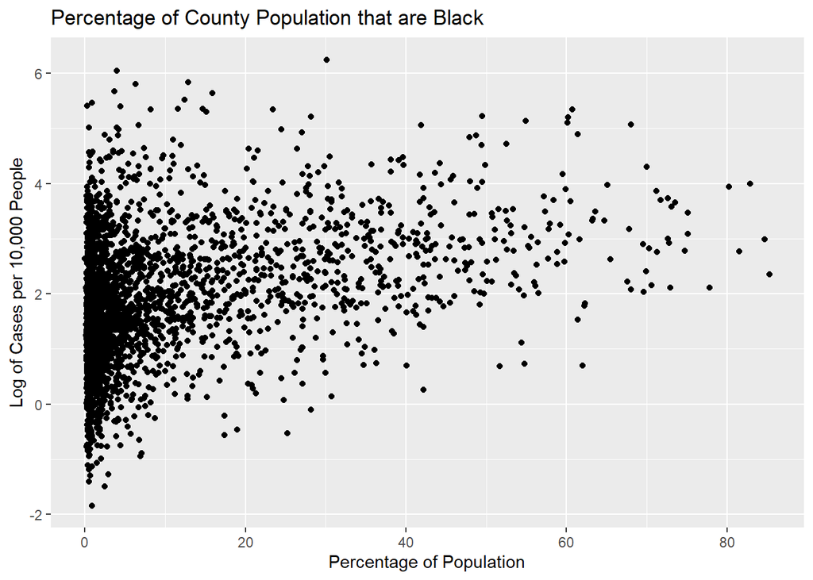

```r
ggplot(corona, aes(x = black, y = log(case.bypop))) +
  geom_point() +
  xlab("Percentage of Population") +
  ylab("Log of Cases per 10,000 People") +
  labs(title = "Percentage of County Population that are Black")
```

It looks as though there could be a trend in the percentage of population of a county that is black as well, although this relationship looks more linear than the previous variable.

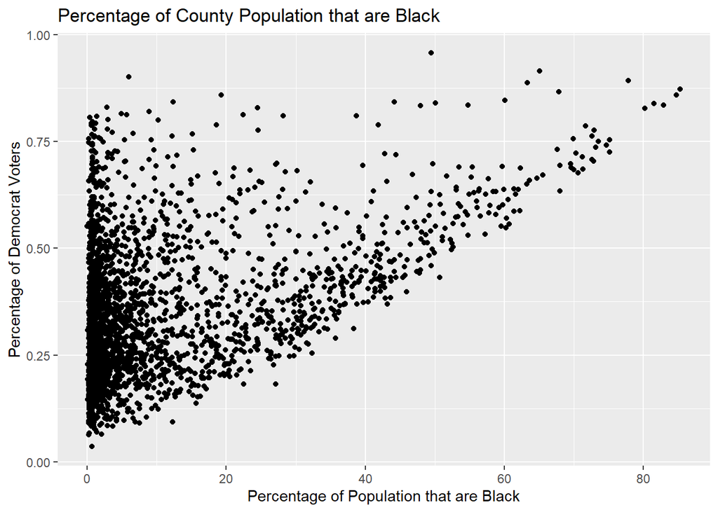

```r
ggplot(corona, aes(x = black, y = DemShare)) +
  geom_point() +
  xlab("Percentage of Population that are Black") +
  ylab("Percentage of Democrat Voters") +
  labs(title = "Percentage of County Population that are Black")
```

Again, the black variable doesn’t have the exact same interaction with DemShare, but it is similar.

The only other data points we have wouldn’t make sense as predictors, such as number of deaths, that just seems like cheating. Now that we have looked at every possible predictor in our data, we can create a model that includes DemShare.

I think that in this case that a parametric model, such as linear regression, is our best choice. From linear regression we have more interpretability of the model than we would with a non-parametric method like a spline or loess.

In order to evaluate our models better we will split our data randomly into a training data set and a test data set. The training data will be 80% of the total data set.

```r
set.seed(8691)
index <- sort(sample(nrow(corona), nrow(corona) * 0.8))
corona.train <- corona[index,]
corona.test <- corona[-index,]
```

```r
corona.lm <- lm(log(case.bypop) ~ DemShare + census_region + log(popdensity) +
                  white + I(white^2) + black, data = corona.train)
summary(corona.lm)
```

```
##
## Call:
## lm(formula = log(case.bypop) ~ DemShare + census_region + log(popdensity) +
##     white + I(white^2) + black, data = corona.train)
##
## Residuals:
##     Min      1Q  Median      3Q     Max
## -3.5453 -0.6786 -0.0541  0.5869  4.7441
##
## Coefficients:
##                          Estimate Std. Error t value Pr(>|t|)
## (Intercept)            -0.0046536  0.4318484  -0.011    0.991
## DemShare                0.0136735  0.2148042   0.064    0.949
## census_regionNortheast  0.7193399  0.0935834   7.687 2.25e-14 ***
## census_regionSouth     -0.2657934  0.0604700  -4.395 1.16e-05 ***
## census_regionWest       0.1200866  0.0802476   1.496    0.135
## log(popdensity)         0.1513539  0.0179959   8.410  < 2e-16 ***
## white                   0.0421342  0.0102838   4.097 4.33e-05 ***
## I(white^2)             -0.0003435  0.0000702  -4.893 1.06e-06 ***
## black                   0.0268684  0.0034092   7.881 5.03e-15 ***
## ---
## Signif. codes:  0 '***' 0.001 '**' 0.01 '*' 0.05 '.' 0.1 ' ' 1
##
## Residual standard error: 1.03 on 2225 degrees of freedom
## Multiple R-squared:  0.2515, Adjusted R-squared:  0.2488
## F-statistic: 93.43 on 8 and 2225 DF,  p-value: < 2.2e-16
```

We can interpret the DemShare coefficient in the following way. With all else equal, a 1% increase in DemShare increases the log cases per 10,000 people by about 1.01%.

```r
exp(0.0136735)
```

```
## [1] 1.013767
```

Let’s take a look at the residuals from this model.

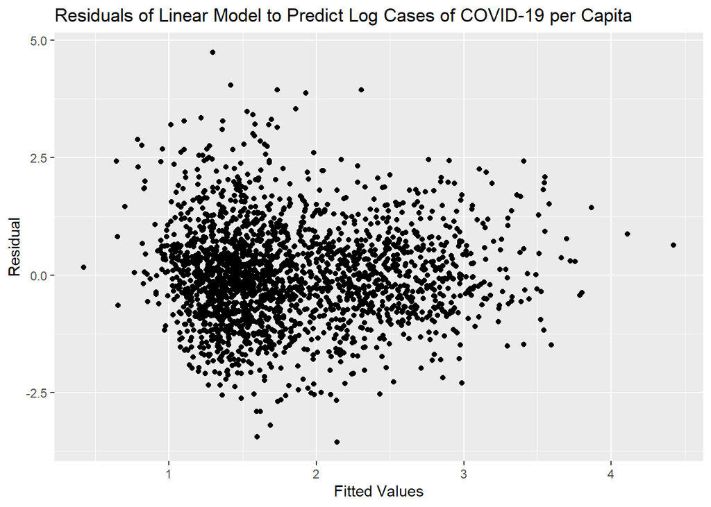

```r
library(broom)
corona.df <- augment(corona.lm)
ggplot(corona.df, aes(x = .fitted, y = .resid)) +
  geom_point() +
  xlab("Fitted Values") +
  ylab("Residual") +
  labs(title = "Residuals of Linear Model to Predict Log Cases of COVID-19 per Capita")
```

The residual plot is not perfectly homoskedastistic, but it isn’t terribly heteroskedastistic. We are mostly using this plot so that we can compare it to our model without DemShare in it. As another measure of the model, we can look at the AIC.

```r
AIC(corona.lm)
```

```
## [1] 6484.724
```

Next we can look at the RMSE of the residuals of the training data.

```r
corona.lm.rmse <- sqrt(mean((corona.df$log.case.bypop. - corona.df$.fitted)^2))
corona.lm.rmse
```

```
## [1] 1.02835
```

Lastly, let’s see how this model predicts our test data set.

```r
corona.lm.pred <- predict(corona.lm, newdata = corona.test)
corona.test$pred <- corona.lm.pred
```

We will use RMSE again as a measurement of performance on the test dataset.

```r
corona.test.rmse <- sqrt(mean((corona.test$pred - log(corona.test$case.bypop))^2))
corona.test.rmse
```

```
## [1] 0.9429298
```

Let’s look at trying to do some feature selection to see if we can improve the model.

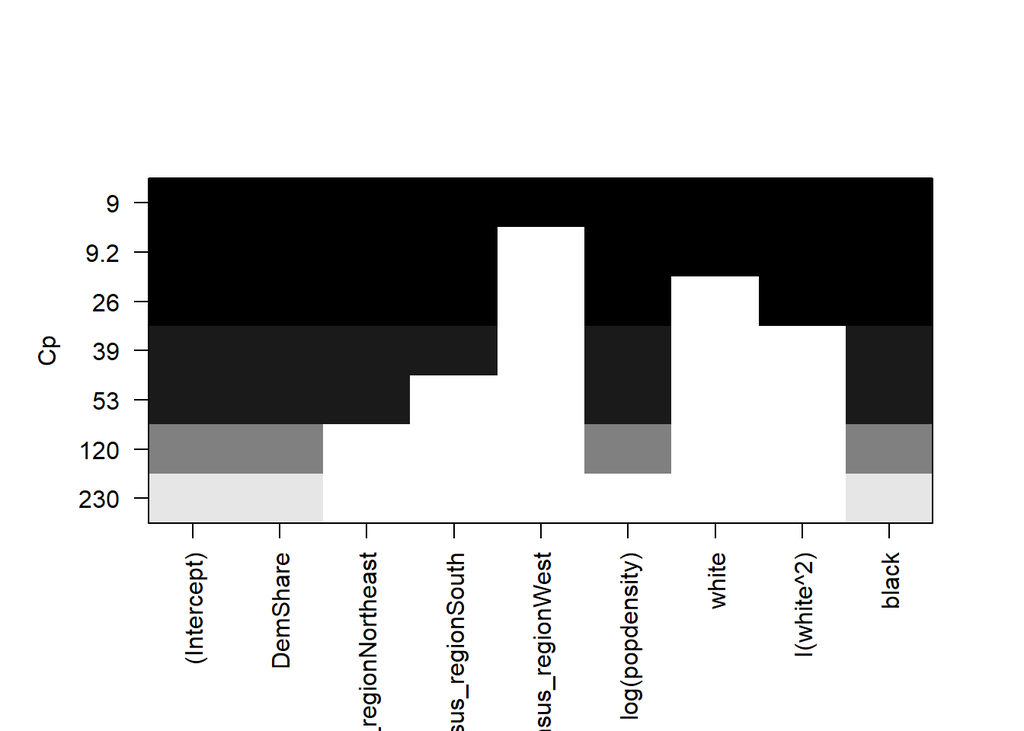

```r
library(leaps)
corona.subset <- regsubsets(log(case.bypop) ~ DemShare + census_region + log(popdensity) +
                              white + I(white^2) + black, force.in = "DemShare", data = corona.train)
plot(corona.subset, scale = "Cp")
```

Actually the best model we could get by forcing in DemShare, is the model we had previously. So let’s look at what happens when we remove DemShare.

```r
corona.lm2 <- lm(log(case.bypop) ~ census_region + log(popdensity) +
                   white + I(white^2) + black, data = corona.train)
summary(corona.lm2)
```

```
##
## Call:
## lm(formula = log(case.bypop) ~ census_region + log(popdensity) +
##     white + I(white^2) + black, data = corona.train)
##
## Residuals:
##     Min      1Q  Median      3Q     Max
## -3.5465 -0.6776 -0.0540  0.5871  4.7439
##
## Coefficients:
##                          Estimate Std. Error t value Pr(>|t|)
## (Intercept)             6.002e-03  3.980e-01   0.015    0.988
## census_regionNortheast  7.203e-01  9.233e-02   7.801 9.35e-15 ***
## census_regionSouth     -2.670e-01  5.721e-02  -4.668 3.22e-06 ***
## census_regionWest       1.214e-01  7.733e-02   1.570    0.116
## log(popdensity)         1.519e-01  1.544e-02   9.840  < 2e-16 ***
## white                   4.198e-02  9.991e-03   4.202 2.75e-05 ***
## I(white^2)             -3.429e-04  6.942e-05  -4.939 8.43e-07 ***
## black                   2.689e-02  3.384e-03   7.947 3.01e-15 ***
## ---
## Signif. codes:  0 '***' 0.001 '**' 0.01 '*' 0.05 '.' 0.1 ' ' 1
##
## Residual standard error: 1.03 on 2226 degrees of freedom
## Multiple R-squared:  0.2515, Adjusted R-squared:  0.2491
## F-statistic: 106.8 on 7 and 2226 DF,  p-value: < 2.2e-16
```

We can see how the residuals plot has changed by removing DemShare.

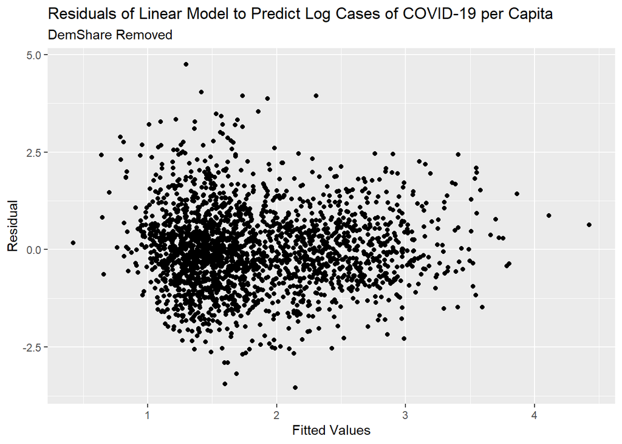

```r
corona.df2 <- augment(corona.lm2)
ggplot(corona.df2, aes(x = .fitted, y = .resid)) +
  geom_point() +
  xlab("Fitted Values") +
  ylab("Residual") +
  labs(title = "Residuals of Linear Model to Predict Log Cases of COVID-19 per Capita",
       subtitle = "DemShare Removed")
```

The residuals plot looks nearly identical to the plot that included DemShare.

Now we can evaluate this new model based on the same measures we did on the previous model that included DemShare.

```r
AIC(corona.lm2)
```

```
## [1] 6482.728
```

We get a slightly reduced AIC. This reduction does mean the model is better, but it is such a slight reduction that it likely isn’t that much of an improvement.

```r
corona.lm2.rmse <- sqrt(mean((corona.df2$log.case.bypop. - corona.df2$.fitted)^2))
corona.lm2.rmse
```

```
## [1] 1.028351
```

As far as the RMSE on the training data, we actually get the slightest increase in RMSE, an increase of 0.000001. This is such a negligible increase that I would say that the RMSEs are the same.

We will use RMSE again as a measurement of performance on the test dataset.

```r
corona.lm2.pred <- predict(corona.lm2, newdata = corona.test)
corona.test$pred2 <- corona.lm2.pred
corona.test.rmse <- sqrt(mean((corona.test$pred2 - log(corona.test$case.bypop))^2))
corona.test.rmse
```

```
## [1] 0.9428813
```

The RMSE on the test data decreases slightly in the model that does not include DemShare, again the decrease is so small that it really isn’t significantly worse or better. So this model likely isn’t better or worse in terms of prediction than the model that included DemShare.

Lastly we can do an ANOVA test to further determine if these models are different.

```r
anova(corona.lm, corona.lm2)
```

|  | Res.Df | RSS | Df | Sum of Sq | F | Pr(>F) |
| --- | --- | --- | --- | --- | --- | --- |
| 1 | 2225 | 2362.465 | NA | NA | NA | NA |
| 2 | 2226 | 2362.469 | -1 | -0.004302387 | 0.004052044 | 0.9492501 |

While we shouldn’t take the P-Value literally, we see that we get an exceptionally high P-Value for the anova test suggesting that there is no statistical difference between the models. If we were selecting models and both are the same, then going with the simpler model would be desired, meaning we would use the model that doesn’t include DemShare.

After these tests, we see that there is basically no difference in the models that include DemShare or don’t include it. As there really is no difference, I would say that there really is no real credence to the fact that COVID-19 spreads faster based on how people vote.

I believe the true reason that there seems to be this relationship between DemShare and COVID-19 cases per capita is that there are variables that predict the spread of infection that also relate to DemShare. For example, the population density makes sense as a predictor of per capita infections because the closer people are to each other the more readily a virus can spread.

```r
cor(corona$DemShare, corona$popdensity)
```

```
## [1] 0.3638465
```

We see that there is a correlation between population density and DemShare at the county level. Generally more heavily populated cities tend to have a higher percentage of Democrat voters than more rural area.

```r
cor(corona$DemShare, corona$white)
```

```
## [1] -0.5472289
```

Another variable that we found that was significant in predicting COVID-19 spread is the percentage of the population that is white. This also has a decent correlation with DemShare, and a similar relationship. While it isn’t known why the percentage of the population that is white would effect transmission, it does seem to be a good predictor in our model.

We have found convincingly that DemShare isn’t a necessary predictor for log of COVID-19 cases per 10,000 people, but there are predictors that are related to DemShare. It would seem as though the counties that have a higher DemShare also share other variables that we can account for in our model and does not require the DemShare to be included.